```python
!jupyter nbconvert --to html INN_ReneWind_Main_Project_FullCode_Notebook.ipynb
```

```
[NbConvertApp] Converting notebook INN_ReneWind_Main_Project_FullCode_Notebook.ipynb to html
[NbConvertApp] WARNING | Alternative text is missing on 49 image(s).
[NbConvertApp] Writing 3577871 bytes to INN_ReneWind_Main_Project_FullCode_Notebook.html
```

# **Problem Statement**

## Business Context

Renewable energy sources play an increasingly important role in the global energy mix, as the effort to reduce the environmental impact of energy production increases.

Out of all the renewable energy alternatives, wind energy is one of the most developed technologies worldwide. The U.S Department of Energy has put together a guide to achieving operational efficiency using predictive maintenance practices.

Predictive maintenance uses sensor information and analysis methods to measure and predict degradation and future component capability. The idea behind predictive maintenance is that failure patterns are predictable and if component failure can be predicted accurately and the component is replaced before it fails, the costs of operation and maintenance will be much lower.

The sensors fitted across different machines involved in the process of energy generation collect data related to various environmental factors (temperature, humidity, wind speed, etc.) and additional features related to various parts of the wind turbine (gearbox, tower, blades, break, etc.).

## Objective

“ReneWind” is a company working on improving the machinery/processes involved in the production of wind energy using machine learning and has collected data of generator failure of wind turbines using sensors. They have shared a ciphered version of the data, as the data collected through sensors is confidential (the type of data collected varies with companies). Data has 40 predictors, 20000 observations in the training set and 5000 in the test set.

The objective is to build various classification models, tune them, and find the best one that will help identify failures so that the generators could be repaired before failing/breaking to reduce the overall maintenance cost. The nature of predictions made by the classification model will translate as follows:

- True positives (TP) are failures correctly predicted by the model. These will result in repairing costs.
- False negatives (FN) are real failures where there is no detection by the model. These will result in replacement costs.
- False positives (FP) are detections where there is no failure. These will result in inspection costs.

It is given that the cost of repairing a generator is much less than the cost of replacing it, and the cost of inspection is less than the cost of repair.

“1” in the target variables should be considered as “failure” and “0” represents “No failure”.

Use:

-Primary Metric: Recall -Secondary Metric: F1 Score or Precision

Because the most expensive mistake in this problem is:

-False Negative (FN) → the model misses a real generator failure → leads to generator replacement cost, downtime, operational disruption, and possibly safety risk.

The business statement explicitly says:

-Replacement cost >> Repair cost >> Inspection cost

So the priority is:

1. Detect as many actual failures as possible
2. Even if it causes some extra inspections or repairs

This helps ensure the model does not create an excessive number of false alarms while still capturing failures.

⸻

## Data Description

The data provided is a transformed version of the original data which was collected using sensors.

- Train.csv - To be used for training and tuning of models.
- Test.csv - To be used only for testing the performance of the final best model.

Both the datasets consist of 40 predictor variables and 1 target variable.

# **Installing and Importing the necessary libraries**

```python
# Installing the libraries with the specified version
!pip install --no-deps tensorflow==2.19.0 scikit-learn==1.6.1 matplotlib===3.10.0 seaborn==0.13.2 numpy==2.0.2 pandas==2.2.2 -q --user --no-warn-script-location
```

```
   ━━━━━━━━━━━━━━━━━━━━━━━━━━━━━━━━━━━━━━━━ 645.0/645.0 MB 2.8 MB/s eta 0:00:00
```

**Note**:

- After running the above cell, kindly restart the runtime (for Google Colab) or notebook kernel (for Jupyter Notebook), and run all cells sequentially from the next cell.
- On executing the above line of code, you might see a warning regarding package dependencies. This error message can be ignored as the above code ensures that all necessary libraries and their dependencies are maintained to successfully execute the code in **this notebook**.

```python
# Library for data manipulation and analysis.
import pandas as pd
# Fundamental package for scientific computing.
import numpy as np
#splitting datasets into training and testing sets.
from sklearn.model_selection import train_test_split
#Imports tools for data preprocessing including label encoding, one-hot encoding, and standard scaling
from sklearn.preprocessing import LabelEncoder, OneHotEncoder,StandardScaler
#Imports a class for imputing missing values in datasets.
from sklearn.impute import SimpleImputer
#Imports the Matplotlib library for creating visualizations.
from sklearn.metrics import confusion_matrix
import matplotlib.pyplot as plt
# Imports the Seaborn library for statistical data visualization.
import seaborn as sns
# Time related functions.
import time
#Imports functions for evaluating the performance of machine learning models
from sklearn.metrics import confusion_matrix, f1_score,accuracy_score, recall_score, precision_score, classification_report
#Imports metrics from
from sklearn import metrics

#Imports the tensorflow,keras and layers.
import tensorflow as tf
from tensorflow.keras.models import Sequential
from tensorflow.keras.layers import Dense, Input, Dropout,BatchNormalization
from tensorflow.keras import backend

# to suppress unnecessary warnings
import warnings
warnings.filterwarnings("ignore")
```

# **Loading the Data**

```python
# uncomment and run the following lines for Google Colab
# from google.colab import drive
# drive.mount('/content/drive')
```

```python
df = pd.read_csv("Train.csv")    # Complete the code to import the training data
df_test = pd.read_csv("Test.csv")    # Complete the code to import the test data
```

```python
data = df.copy() # Copy of the training data
```

```python
# let's create a copy of the testing  data
data_test = df_test.copy()
```

# **Data Overview**

```python
data.head()
```

|  | V1 | V2 | V3 | V4 | V5 | V6 | V7 | V8 | V9 | V10 | ... | V32 | V33 | V34 | V35 | V36 | V37 | V38 | V39 | V40 | Target |
| --- | --- | --- | --- | --- | --- | --- | --- | --- | --- | --- | --- | --- | --- | --- | --- | --- | --- | --- | --- | --- | --- |
| 0 | -4.464606 | -4.679129 | 3.101546 | 0.506130 | -0.221083 | -2.032511 | -2.910870 | 0.050714 | -1.522351 | 3.761892 | ... | 3.059700 | -1.690440 | 2.846296 | 2.235198 | 6.667486 | 0.443809 | -2.369169 | 2.950578 | -3.480324 | 0 |
| 1 | 3.365912 | 3.653381 | 0.909671 | -1.367528 | 0.332016 | 2.358938 | 0.732600 | -4.332135 | 0.565695 | -0.101080 | ... | -1.795474 | 3.032780 | -2.467514 | 1.894599 | -2.297780 | -1.731048 | 5.908837 | -0.386345 | 0.616242 | 0 |
| 2 | -3.831843 | -5.824444 | 0.634031 | -2.418815 | -1.773827 | 1.016824 | -2.098941 | -3.173204 | -2.081860 | 5.392621 | ... | -0.257101 | 0.803550 | 4.086219 | 2.292138 | 5.360850 | 0.351993 | 2.940021 | 3.839160 | -4.309402 | 0 |
| 3 | 1.618098 | 1.888342 | 7.046143 | -1.147285 | 0.083080 | -1.529780 | 0.207309 | -2.493629 | 0.344926 | 2.118578 | ... | -3.584425 | -2.577474 | 1.363769 | 0.622714 | 5.550100 | -1.526796 | 0.138853 | 3.101430 | -1.277378 | 0 |
| 4 | -0.111440 | 3.872488 | -3.758361 | -2.982897 | 3.792714 | 0.544960 | 0.205433 | 4.848994 | -1.854920 | -6.220023 | ... | 8.265896 | 6.629213 | -10.068689 | 1.222987 | -3.229763 | 1.686909 | -2.163896 | -3.644622 | 6.510338 | 0 |

5 rows × 41 columns

```python
data.tail()
```

|  | V1 | V2 | V3 | V4 | V5 | V6 | V7 | V8 | V9 | V10 | ... | V32 | V33 | V34 | V35 | V36 | V37 | V38 | V39 | V40 | Target |
| --- | --- | --- | --- | --- | --- | --- | --- | --- | --- | --- | --- | --- | --- | --- | --- | --- | --- | --- | --- | --- | --- |
| 19995 | -2.071318 | -1.088279 | -0.796174 | -3.011720 | -2.287540 | 2.807310 | 0.481428 | 0.105171 | -0.586599 | -2.899398 | ... | -8.273996 | 5.745013 | 0.589014 | -0.649988 | -3.043174 | 2.216461 | 0.608723 | 0.178193 | 2.927755 | 1 |
| 19996 | 2.890264 | 2.483069 | 5.643919 | 0.937053 | -1.380870 | 0.412051 | -1.593386 | -5.762498 | 2.150096 | 0.272302 | ... | -4.159092 | 1.181466 | -0.742412 | 5.368979 | -0.693028 | -1.668971 | 3.659954 | 0.819863 | -1.987265 | 0 |
| 19997 | -3.896979 | -3.942407 | -0.351364 | -2.417462 | 1.107546 | -1.527623 | -3.519882 | 2.054792 | -0.233996 | -0.357687 | ... | 7.112162 | 1.476080 | -3.953710 | 1.855555 | 5.029209 | 2.082588 | -6.409304 | 1.477138 | -0.874148 | 0 |
| 19998 | -3.187322 | -10.051662 | 5.695955 | -4.370053 | -5.354758 | -1.873044 | -3.947210 | 0.679420 | -2.389254 | 5.456756 | ... | 0.402812 | 3.163661 | 3.752095 | 8.529894 | 8.450626 | 0.203958 | -7.129918 | 4.249394 | -6.112267 | 0 |
| 19999 | -2.686903 | 1.961187 | 6.137088 | 2.600133 | 2.657241 | -4.290882 | -2.344267 | 0.974004 | -1.027462 | 0.497421 | ... | 6.620811 | -1.988786 | -1.348901 | 3.951801 | 5.449706 | -0.455411 | -2.202056 | 1.678229 | -1.974413 | 0 |

5 rows × 41 columns

```python
data_test.head()
```

|  | V1 | V2 | V3 | V4 | V5 | V6 | V7 | V8 | V9 | V10 | ... | V32 | V33 | V34 | V35 | V36 | V37 | V38 | V39 | V40 | Target |
| --- | --- | --- | --- | --- | --- | --- | --- | --- | --- | --- | --- | --- | --- | --- | --- | --- | --- | --- | --- | --- | --- |
| 0 | -0.613489 | -3.819640 | 2.202302 | 1.300420 | -1.184929 | -4.495964 | -1.835817 | 4.722989 | 1.206140 | -0.341909 | ... | 2.291204 | -5.411388 | 0.870073 | 0.574479 | 4.157191 | 1.428093 | -10.511342 | 0.454664 | -1.448363 | 0 |
| 1 | 0.389608 | -0.512341 | 0.527053 | -2.576776 | -1.016766 | 2.235112 | -0.441301 | -4.405744 | -0.332869 | 1.966794 | ... | -2.474936 | 2.493582 | 0.315165 | 2.059288 | 0.683859 | -0.485452 | 5.128350 | 1.720744 | -1.488235 | 0 |
| 2 | -0.874861 | -0.640632 | 4.084202 | -1.590454 | 0.525855 | -1.957592 | -0.695367 | 1.347309 | -1.732348 | 0.466500 | ... | -1.318888 | -2.997464 | 0.459664 | 0.619774 | 5.631504 | 1.323512 | -1.752154 | 1.808302 | 1.675748 | 0 |
| 3 | 0.238384 | 1.458607 | 4.014528 | 2.534478 | 1.196987 | -3.117330 | -0.924035 | 0.269493 | 1.322436 | 0.702345 | ... | 3.517918 | -3.074085 | -0.284220 | 0.954576 | 3.029331 | -1.367198 | -3.412140 | 0.906000 | -2.450889 | 0 |
| 4 | 5.828225 | 2.768260 | -1.234530 | 2.809264 | -1.641648 | -1.406698 | 0.568643 | 0.965043 | 1.918379 | -2.774855 | ... | 1.773841 | -1.501573 | -2.226702 | 4.776830 | -6.559698 | -0.805551 | -0.276007 | -3.858207 | -0.537694 | 0 |

5 rows × 41 columns

```python
data_test.tail()
```

|  | V1 | V2 | V3 | V4 | V5 | V6 | V7 | V8 | V9 | V10 | ... | V32 | V33 | V34 | V35 | V36 | V37 | V38 | V39 | V40 | Target |
| --- | --- | --- | --- | --- | --- | --- | --- | --- | --- | --- | --- | --- | --- | --- | --- | --- | --- | --- | --- | --- | --- |
| 4995 | -5.120451 | 1.634804 | 1.251259 | 4.035944 | 3.291204 | -2.932230 | -1.328662 | 1.754066 | -2.984586 | 1.248633 | ... | 9.979118 | 0.063438 | 0.217281 | 3.036388 | 2.109323 | -0.557433 | 1.938718 | 0.512674 | -2.694194 | 0 |
| 4996 | -5.172498 | 1.171653 | 1.579105 | 1.219922 | 2.529627 | -0.668648 | -2.618321 | -2.000545 | 0.633791 | -0.578938 | ... | 4.423900 | 2.603811 | -2.152170 | 0.917401 | 2.156586 | 0.466963 | 0.470120 | 2.196756 | -2.376515 | 0 |
| 4997 | -1.114136 | -0.403576 | -1.764875 | -5.879475 | 3.571558 | 3.710802 | -2.482952 | -0.307614 | -0.921945 | -2.999141 | ... | 3.791778 | 7.481506 | -10.061396 | -0.387166 | 1.848509 | 1.818248 | -1.245633 | -1.260876 | 7.474682 | 0 |
| 4998 | -1.703241 | 0.614650 | 6.220503 | -0.104132 | 0.955916 | -3.278706 | -1.633855 | -0.103936 | 1.388152 | -1.065622 | ... | -4.100352 | -5.949325 | 0.550372 | -1.573640 | 6.823936 | 2.139307 | -4.036164 | 3.436051 | 0.579249 | 0 |
| 4999 | -0.603701 | 0.959550 | -0.720995 | 8.229574 | -1.815610 | -2.275547 | -2.574524 | -1.041479 | 4.129645 | -2.731288 | ... | 2.369776 | -1.062408 | 0.790772 | 4.951955 | -7.440825 | -0.069506 | -0.918083 | -2.291154 | -5.362891 | 0 |

5 rows × 41 columns

```python
data.shape
```

```
(20000, 41)
```

```python
data_test.shape
```

```
(5000, 41)
```

```python
data.describe().T
```

|  | count | mean | std | min | 25% | 50% | 75% | max |
| --- | --- | --- | --- | --- | --- | --- | --- | --- |
| V1 | 19982.0 | -0.271996 | 3.441625 | -11.876451 | -2.737146 | -0.747917 | 1.840112 | 15.493002 |
| V2 | 19982.0 | 0.440430 | 3.150784 | -12.319951 | -1.640674 | 0.471536 | 2.543967 | 13.089269 |
| V3 | 20000.0 | 2.484699 | 3.388963 | -10.708139 | 0.206860 | 2.255786 | 4.566165 | 17.090919 |
| V4 | 20000.0 | -0.083152 | 3.431595 | -15.082052 | -2.347660 | -0.135241 | 2.130615 | 13.236381 |
| V5 | 20000.0 | -0.053752 | 2.104801 | -8.603361 | -1.535607 | -0.101952 | 1.340480 | 8.133797 |
| V6 | 20000.0 | -0.995443 | 2.040970 | -10.227147 | -2.347238 | -1.000515 | 0.380330 | 6.975847 |
| V7 | 20000.0 | -0.879325 | 1.761626 | -7.949681 | -2.030926 | -0.917179 | 0.223695 | 8.006091 |
| V8 | 20000.0 | -0.548195 | 3.295756 | -15.657561 | -2.642665 | -0.389085 | 1.722965 | 11.679495 |
| V9 | 20000.0 | -0.016808 | 2.160568 | -8.596313 | -1.494973 | -0.067597 | 1.409203 | 8.137580 |
| V10 | 20000.0 | -0.012998 | 2.193201 | -9.853957 | -1.411212 | 0.100973 | 1.477045 | 8.108472 |
| V11 | 20000.0 | -1.895393 | 3.124322 | -14.832058 | -3.922404 | -1.921237 | 0.118906 | 11.826433 |
| V12 | 20000.0 | 1.604825 | 2.930454 | -12.948007 | -0.396514 | 1.507841 | 3.571454 | 15.080698 |
| V13 | 20000.0 | 1.580486 | 2.874658 | -13.228247 | -0.223545 | 1.637185 | 3.459886 | 15.419616 |
| V14 | 20000.0 | -0.950632 | 1.789651 | -7.738593 | -2.170741 | -0.957163 | 0.270677 | 5.670664 |
| V15 | 20000.0 | -2.414993 | 3.354974 | -16.416606 | -4.415322 | -2.382617 | -0.359052 | 12.246455 |
| V16 | 20000.0 | -2.925225 | 4.221717 | -20.374158 | -5.634240 | -2.682705 | -0.095046 | 13.583212 |
| V17 | 20000.0 | -0.134261 | 3.345462 | -14.091184 | -2.215611 | -0.014580 | 2.068751 | 16.756432 |
| V18 | 20000.0 | 1.189347 | 2.592276 | -11.643994 | -0.403917 | 0.883398 | 2.571770 | 13.179863 |
| V19 | 20000.0 | 1.181808 | 3.396925 | -13.491784 | -1.050168 | 1.279061 | 3.493299 | 13.237742 |
| V20 | 20000.0 | 0.023608 | 3.669477 | -13.922659 | -2.432953 | 0.033415 | 2.512372 | 16.052339 |
| V21 | 20000.0 | -3.611252 | 3.567690 | -17.956231 | -5.930360 | -3.532888 | -1.265884 | 13.840473 |
| V22 | 20000.0 | 0.951835 | 1.651547 | -10.122095 | -0.118127 | 0.974687 | 2.025594 | 7.409856 |
| V23 | 20000.0 | -0.366116 | 4.031860 | -14.866128 | -3.098756 | -0.262093 | 2.451750 | 14.458734 |
| V24 | 20000.0 | 1.134389 | 3.912069 | -16.387147 | -1.468062 | 0.969048 | 3.545975 | 17.163291 |
| V25 | 20000.0 | -0.002186 | 2.016740 | -8.228266 | -1.365178 | 0.025050 | 1.397112 | 8.223389 |
| V26 | 20000.0 | 1.873785 | 3.435137 | -11.834271 | -0.337863 | 1.950531 | 4.130037 | 16.836410 |
| V27 | 20000.0 | -0.612413 | 4.368847 | -14.904939 | -3.652323 | -0.884894 | 2.189177 | 17.560404 |
| V28 | 20000.0 | -0.883218 | 1.917713 | -9.269489 | -2.171218 | -0.891073 | 0.375884 | 6.527643 |
| V29 | 20000.0 | -0.985625 | 2.684365 | -12.579469 | -2.787443 | -1.176181 | 0.629773 | 10.722055 |
| V30 | 20000.0 | -0.015534 | 3.005258 | -14.796047 | -1.867114 | 0.184346 | 2.036229 | 12.505812 |
| V31 | 20000.0 | 0.486842 | 3.461384 | -13.722760 | -1.817772 | 0.490304 | 2.730688 | 17.255090 |
| V32 | 20000.0 | 0.303799 | 5.500400 | -19.876502 | -3.420469 | 0.052073 | 3.761722 | 23.633187 |
| V33 | 20000.0 | 0.049825 | 3.575285 | -16.898353 | -2.242857 | -0.066249 | 2.255134 | 16.692486 |
| V34 | 20000.0 | -0.462702 | 3.183841 | -17.985094 | -2.136984 | -0.255008 | 1.436935 | 14.358213 |
| V35 | 20000.0 | 2.229620 | 2.937102 | -15.349803 | 0.336191 | 2.098633 | 4.064358 | 15.291065 |
| V36 | 20000.0 | 1.514809 | 3.800860 | -14.833178 | -0.943809 | 1.566526 | 3.983939 | 19.329576 |
| V37 | 20000.0 | 0.011316 | 1.788165 | -5.478350 | -1.255819 | -0.128435 | 1.175533 | 7.467006 |
| V38 | 20000.0 | -0.344025 | 3.948147 | -17.375002 | -2.987638 | -0.316849 | 2.279399 | 15.289923 |
| V39 | 20000.0 | 0.890653 | 1.753054 | -6.438880 | -0.272250 | 0.919261 | 2.057540 | 7.759877 |
| V40 | 20000.0 | -0.875630 | 3.012155 | -11.023935 | -2.940193 | -0.920806 | 1.119897 | 10.654265 |
| Target | 20000.0 | 0.055500 | 0.228959 | 0.000000 | 0.000000 | 0.000000 | 0.000000 | 1.000000 |

```python
data_test.describe().T
```

|  | count | mean | std | min | 25% | 50% | 75% | max |
| --- | --- | --- | --- | --- | --- | --- | --- | --- |
| V1 | 4995.0 | -0.277622 | 3.466280 | -12.381696 | -2.743691 | -0.764767 | 1.831313 | 13.504352 |
| V2 | 4994.0 | 0.397928 | 3.139562 | -10.716179 | -1.649211 | 0.427369 | 2.444486 | 14.079073 |
| V3 | 5000.0 | 2.551787 | 3.326607 | -9.237940 | 0.314931 | 2.260428 | 4.587000 | 15.314503 |
| V4 | 5000.0 | -0.048943 | 3.413937 | -14.682446 | -2.292694 | -0.145753 | 2.166468 | 12.140157 |
| V5 | 5000.0 | -0.080120 | 2.110870 | -7.711569 | -1.615238 | -0.131890 | 1.341197 | 7.672835 |
| V6 | 5000.0 | -1.042138 | 2.005444 | -8.924196 | -2.368853 | -1.048571 | 0.307555 | 5.067685 |
| V7 | 5000.0 | -0.907922 | 1.769017 | -8.124230 | -2.054259 | -0.939695 | 0.212228 | 7.616182 |
| V8 | 5000.0 | -0.574592 | 3.331911 | -12.252731 | -2.642088 | -0.357943 | 1.712896 | 10.414722 |
| V9 | 5000.0 | 0.030121 | 2.174139 | -6.785495 | -1.455712 | -0.079891 | 1.449548 | 8.850720 |
| V10 | 5000.0 | 0.018524 | 2.145437 | -8.170956 | -1.353320 | 0.166292 | 1.511248 | 6.598728 |
| V11 | 5000.0 | -2.008615 | 3.112220 | -13.151753 | -4.050432 | -2.043122 | 0.044069 | 9.956400 |
| V12 | 5000.0 | 1.576413 | 2.907401 | -8.164048 | -0.449674 | 1.488253 | 3.562626 | 12.983644 |
| V13 | 5000.0 | 1.622456 | 2.882892 | -11.548209 | -0.126012 | 1.718649 | 3.464604 | 12.620041 |
| V14 | 5000.0 | -0.921097 | 1.803470 | -7.813929 | -2.110952 | -0.896011 | 0.272324 | 5.734112 |
| V15 | 5000.0 | -2.452174 | 3.387041 | -15.285768 | -4.479072 | -2.417131 | -0.432943 | 11.673420 |
| V16 | 5000.0 | -3.018503 | 4.264407 | -20.985779 | -5.648343 | -2.773763 | -0.178105 | 13.975843 |
| V17 | 5000.0 | -0.103721 | 3.336513 | -13.418281 | -2.227683 | 0.047462 | 2.111907 | 19.776592 |
| V18 | 5000.0 | 1.195606 | 2.586403 | -12.214016 | -0.408850 | 0.881395 | 2.604014 | 13.642235 |
| V19 | 5000.0 | 1.210490 | 3.384662 | -14.169635 | -1.026394 | 1.295864 | 3.526278 | 12.427997 |
| V20 | 5000.0 | 0.138429 | 3.657171 | -13.719620 | -2.325454 | 0.193386 | 2.539550 | 13.870565 |
| V21 | 5000.0 | -3.664398 | 3.577841 | -16.340707 | -5.944369 | -3.662870 | -1.329645 | 11.046925 |
| V22 | 5000.0 | 0.961960 | 1.640414 | -6.740239 | -0.047728 | 0.986020 | 2.029321 | 7.505291 |
| V23 | 5000.0 | -0.422182 | 4.056714 | -14.422274 | -3.162690 | -0.279222 | 2.425911 | 13.180887 |
| V24 | 5000.0 | 1.088841 | 3.968207 | -12.315545 | -1.623203 | 0.912815 | 3.537195 | 17.806035 |
| V25 | 5000.0 | 0.061235 | 2.010227 | -6.770139 | -1.298377 | 0.076703 | 1.428491 | 6.556937 |
| V26 | 5000.0 | 1.847261 | 3.400330 | -11.414019 | -0.242470 | 1.917032 | 4.156106 | 17.528193 |
| V27 | 5000.0 | -0.552397 | 4.402947 | -13.177038 | -3.662591 | -0.871982 | 2.247257 | 17.290161 |
| V28 | 5000.0 | -0.867678 | 1.926181 | -7.933388 | -2.159811 | -0.930695 | 0.420587 | 7.415659 |
| V29 | 5000.0 | -1.095805 | 2.655454 | -9.987800 | -2.861373 | -1.340547 | 0.521843 | 14.039466 |
| V30 | 5000.0 | -0.118699 | 3.023292 | -12.438434 | -1.996743 | 0.112463 | 1.946450 | 10.314976 |
| V31 | 5000.0 | 0.468810 | 3.446324 | -11.263271 | -1.822421 | 0.485742 | 2.779008 | 12.558928 |
| V32 | 5000.0 | 0.232567 | 5.585628 | -17.244168 | -3.556267 | -0.076694 | 3.751857 | 26.539391 |
| V33 | 5000.0 | -0.080115 | 3.538624 | -14.903781 | -2.348121 | -0.159713 | 2.099160 | 13.323517 |
| V34 | 5000.0 | -0.392663 | 3.166101 | -14.699725 | -2.009604 | -0.171745 | 1.465402 | 12.146302 |
| V35 | 5000.0 | 2.211205 | 2.948426 | -12.260591 | 0.321818 | 2.111750 | 4.031639 | 13.489237 |
| V36 | 5000.0 | 1.594845 | 3.774970 | -12.735567 | -0.866066 | 1.702964 | 4.104409 | 17.116122 |
| V37 | 5000.0 | 0.022931 | 1.785320 | -5.079070 | -1.240526 | -0.110415 | 1.237522 | 6.809938 |
| V38 | 5000.0 | -0.405659 | 3.968936 | -15.334533 | -2.984480 | -0.381162 | 2.287998 | 13.064950 |
| V39 | 5000.0 | 0.938800 | 1.716502 | -5.451050 | -0.208024 | 0.959152 | 2.130769 | 7.182237 |
| V40 | 5000.0 | -0.932406 | 2.978193 | -10.076234 | -2.986587 | -1.002764 | 1.079738 | 8.698460 |
| Target | 5000.0 | 0.056400 | 0.230716 | 0.000000 | 0.000000 | 0.000000 | 0.000000 | 1.000000 |

```python
data.info()  #Check data type for training set
```

```
<class 'pandas.core.frame.DataFrame'>
RangeIndex: 20000 entries, 0 to 19999
Data columns (total 41 columns):
 #   Column  Non-Null Count  Dtype
---  ------  --------------  -----
 0   V1      19982 non-null  float64
 1   V2      19982 non-null  float64
 2   V3      20000 non-null  float64
 3   V4      20000 non-null  float64
 4   V5      20000 non-null  float64
 5   V6      20000 non-null  float64
 6   V7      20000 non-null  float64
 7   V8      20000 non-null  float64
 8   V9      20000 non-null  float64
 9   V10     20000 non-null  float64
```

[output cut: 33 more lines]

```python
data_test.info()  #Check data type for testing set
```

```
<class 'pandas.core.frame.DataFrame'>
RangeIndex: 5000 entries, 0 to 4999
Data columns (total 41 columns):
 #   Column  Non-Null Count  Dtype
---  ------  --------------  -----
 0   V1      4995 non-null   float64
 1   V2      4994 non-null   float64
 2   V3      5000 non-null   float64
 3   V4      5000 non-null   float64
 4   V5      5000 non-null   float64
 5   V6      5000 non-null   float64
 6   V7      5000 non-null   float64
 7   V8      5000 non-null   float64
 8   V9      5000 non-null   float64
 9   V10     5000 non-null   float64
```

[output cut: 33 more lines]

```python
data['Target'] = data['Target'].astype('float64')
```

```python
data_test['Target'] = data_test['Target'].astype('float64')
```

```python
print(f"Number of duplicate rows in training data: {data.duplicated().sum()}")
print(f"Number of duplicate rows in testing data: {data_test.duplicated().sum()}")
```

```
Number of duplicate rows in training data: 0
Number of duplicate rows in testing data: 0
```

```python
print("Missing values in training data (data):")
print(data.isnull().sum())
```

```
Missing values in training data (data):
V1        18
V2        18
V3         0
V4         0
V5         0
V6         0
V7         0
V8         0
V9         0
V10        0
V11        0
V12        0
V13        0
V14        0
V15        0
V16        0
V17        0
V18        0
V19        0
V20        0
V21        0
V22        0
V23        0
V24        0
V25        0
V26        0
V27        0
V28        0
V29        0
V30        0
V31        0
V32        0
V33        0
V34        0
V35        0
V36        0
V37        0
V38        0
V39        0
V40        0
Target     0
dtype: int64
```

```python
print("Missing values in training data (data_test):")
print(data_test.isnull().sum())
```

```
Missing values in training data (data_test):
V1        5
V2        6
V3        0
V4        0
V5        0
V6        0
V7        0
V8        0
V9        0
V10       0
V11       0
V12       0
V13       0
V14       0
V15       0
V16       0
V17       0
V18       0
V19       0
V20       0
V21       0
V22       0
V23       0
V24       0
V25       0
V26       0
V27       0
V28       0
V29       0
V30       0
V31       0
V32       0
V33       0
V34       0
V35       0
V36       0
V37       0
V38       0
V39       0
V40       0
Target    0
dtype: int64
```

```python
#data.dropna(inplace=True) # Drop missing rows in train data, very small.
```

```python
#data.shape
```

# **Exploratory Data Analysis**

## Univariate analysis

```python
# function to plot a boxplot and a histogram along the same scale.

def histogram_boxplot(data, feature, figsize=(12, 7), kde=False, bins=None):
    """
    Boxplot and histogram combined

    data: dataframe
    feature: dataframe column
    figsize: size of figure (default (12,7))
    kde: whether to the show density curve (default False)
    bins: number of bins for histogram (default None)
    """
    f2, (ax_box2, ax_hist2) = plt.subplots(
        nrows=2,  # Number of rows of the subplot grid= 2
        sharex=True,  # x-axis will be shared among all subplots
        gridspec_kw={"height_ratios": (0.25, 0.75)},
        figsize=figsize,
    )  # creating the 2 subplots
    sns.boxplot(
        data=data, x=feature, ax=ax_box2, showmeans=True, color="violet"
    )  # boxplot will be created and a star will indicate the mean value of the column
    sns.histplot(
        data=data, x=feature, kde=kde, ax=ax_hist2, bins=bins
    ) if bins else sns.histplot(
        data=data, x=feature, kde=kde, ax=ax_hist2
    )  # For histogram
    ax_hist2.axvline(
        data[feature].mean(), color="green", linestyle="--"
    )  # Add mean to the histogram
    ax_hist2.axvline(
        data[feature].median(), color="black", linestyle="-"
    )  # Add median to the histogram
```

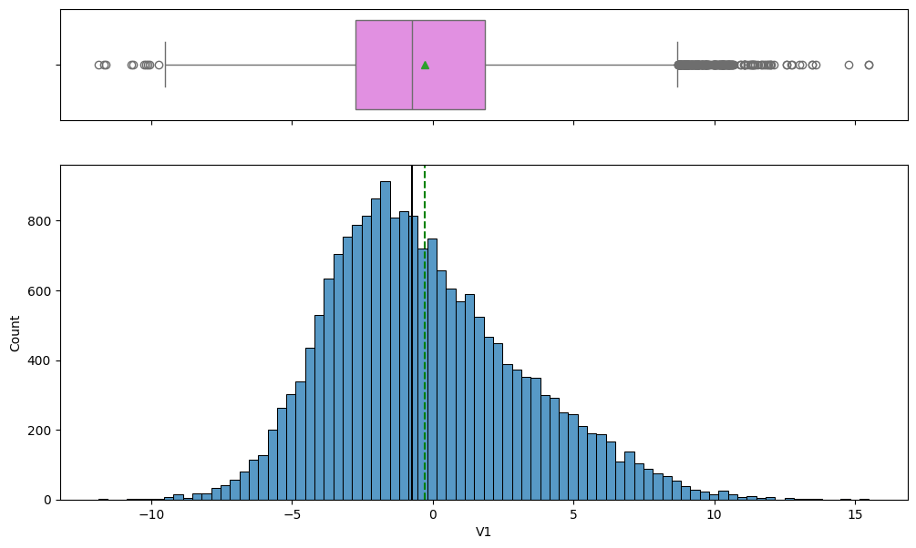

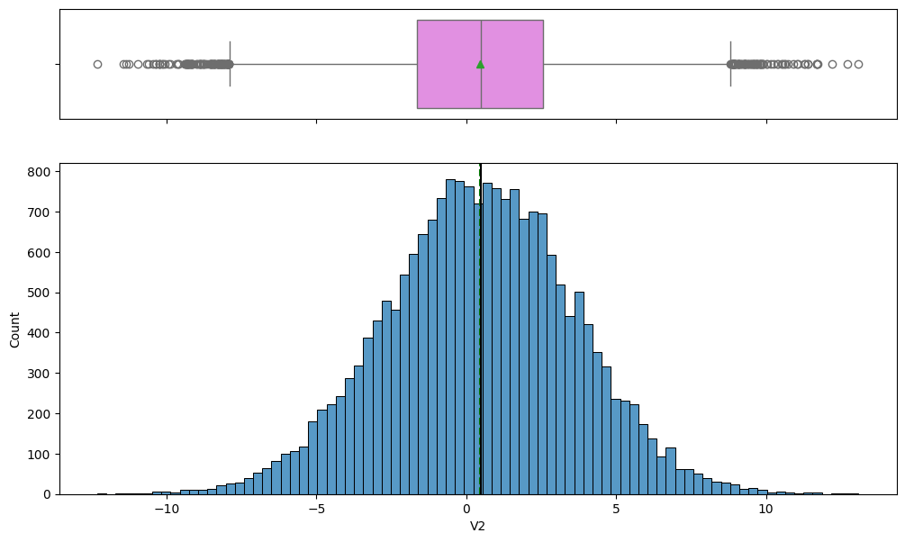

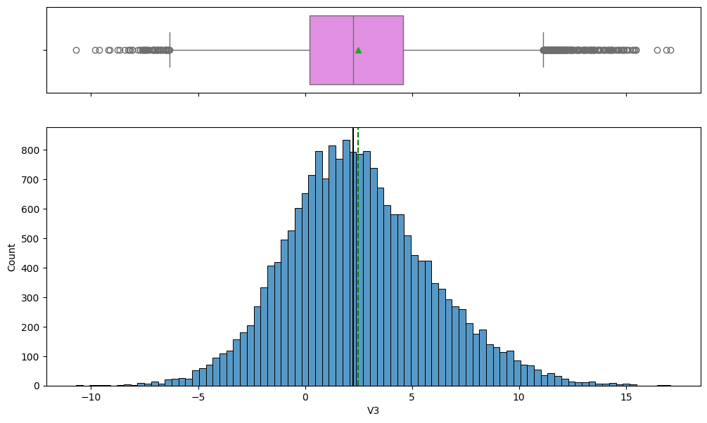

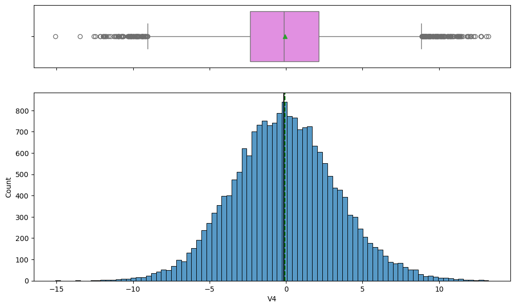

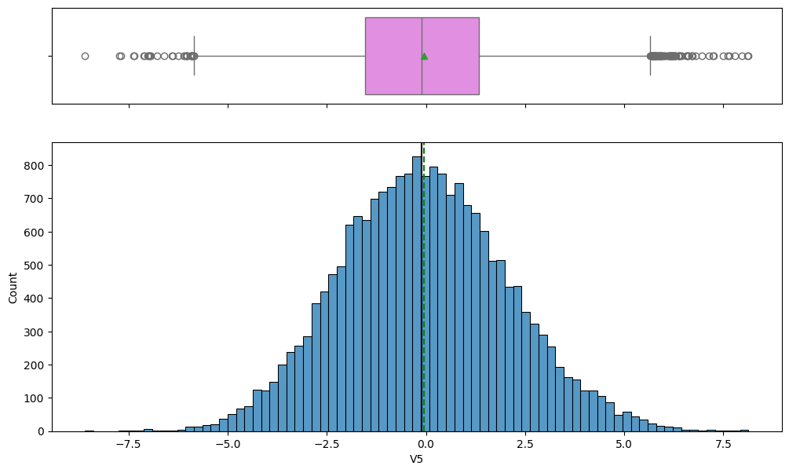

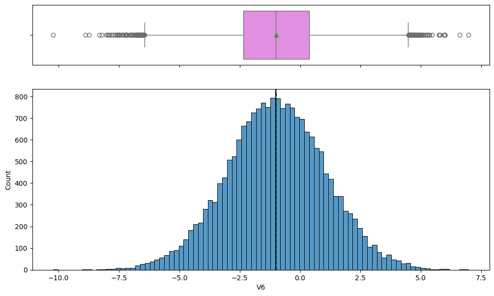

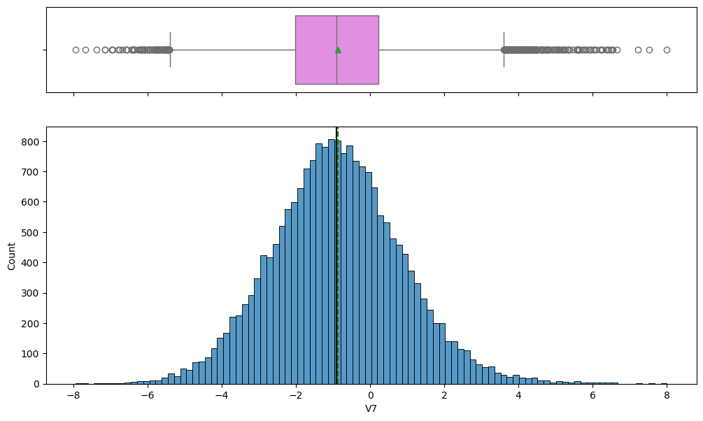

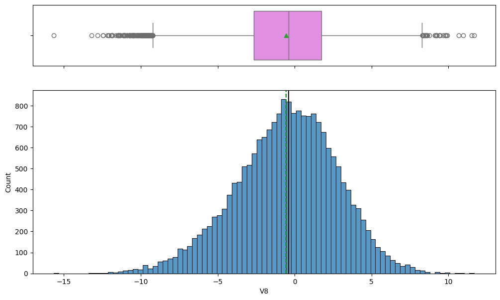

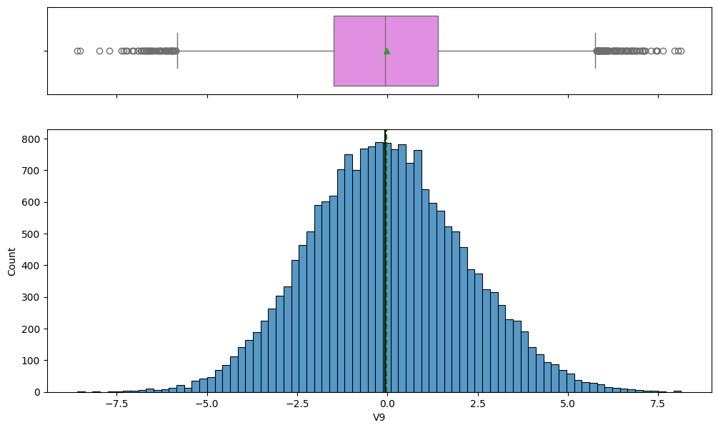

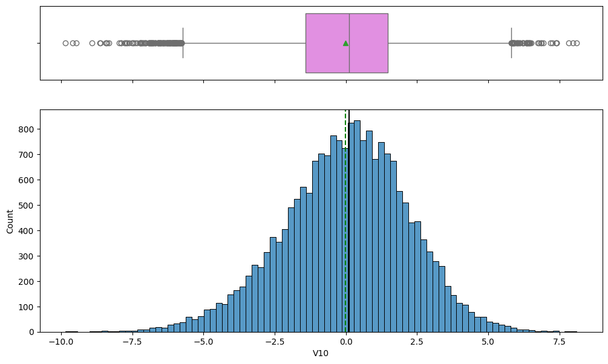

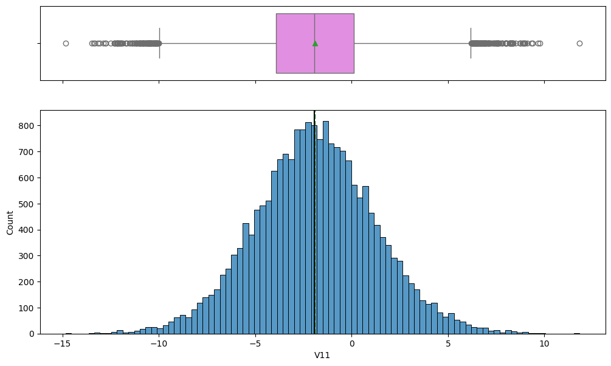

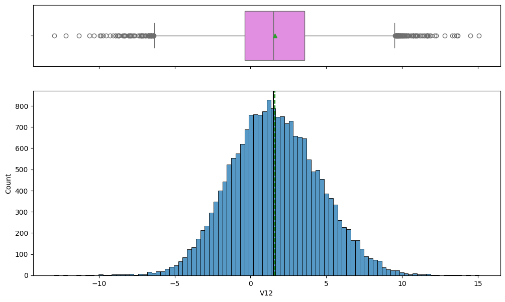

[29 more figures not shown]

```python
for feature in data.columns:
    histogram_boxplot(data, feature, figsize=(12, 7), kde=False, bins=None)
```

### Observations from Univariate Analysis

Check Distribution of Target Variable

```python
# For train data
data["Target"].value_counts(1)
```

| Target | proportion |
| --- | --- |
| 0 | 0.9445 |
| 1 | 0.0555 |

**dtype:** float64

```python
# For test data
data_test["Target"].value_counts(1)
```

| Target | proportion |
| --- | --- |
| 0 | 0.9436 |
| 1 | 0.0564 |

**dtype:** float64

### Observation on Target Variable Distribution

- **Class Imbalance:** Both the training and test datasets exhibit a significant class imbalance. The 'Target' variable (representing 'failure' or 'no failure') shows that the 'no failure' class (0) constitutes approximately 94.45% of the training data and 94.36% of the test data. Conversely, the 'failure' class (1) represents a much smaller proportion, about 5.55% in the training data and 5.64% in the test data. This indicates that failure events are rare, which is typical in predictive maintenance scenarios. It is crucial to address this imbalance during model training to prevent the model from becoming biased towards the majority class and failing to accurately predict the minority (failure) class.

## Bivariate Analysis

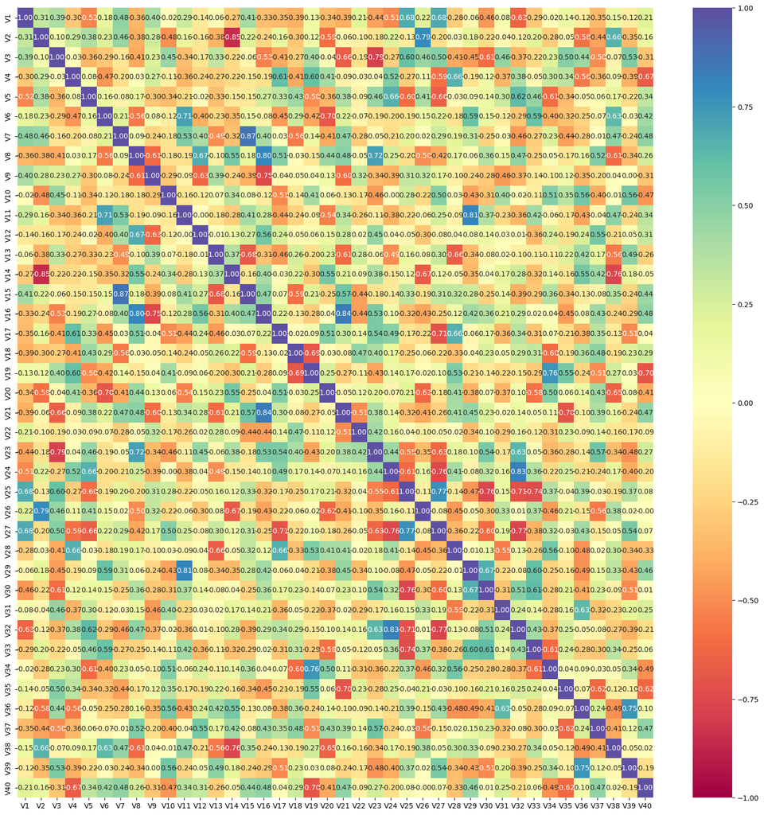

```python
cols_list = data.select_dtypes(include=np.number).columns.tolist()
cols_list.remove("Target")

plt.figure(figsize=(20, 20))
sns.heatmap(
    data[cols_list].corr(), annot=True, vmin=-1, vmax=1, fmt=".2f", cmap="Spectral"
)
plt.show()
```

### Observations from Bivariate Analysis (Correlation Heatmap)

# **Data Preprocessing**

```python
# Dividing train data into X and y
X = data.drop(columns = ["Target"] , axis=1) # Remove the column named 'Target'
y = data["Target"] # Select the column named 'Target' as y train
```

```python
# Splitting data into training and validation set:

X_train, X_val, y_train, y_val = train_test_split(
    X, y, test_size=0.3, random_state=1, stratify=y
)
```

```python
X_train.shape #Check Rows and Columns of X_train data
```

```
(14000, 40)
```

```python
X_val.shape #Check Rows and Columns of X_val data
```

```
(6000, 40)
```

```python
# Dividing test data into X_test and y_test
X_test = data_test.drop(columns = ['Target'] , axis= 1) # Remove the target column
y_test = data_test["Target"] # Select the target column
```

```python
X_test.shape # Check Rows and Columns of Test Data
```

```
(5000, 40)
```

**Missing Value Imputation in Training Data**

```python
imputer = SimpleImputer(strategy="median")
```

```python
# Fit and transform the train data
X_train = pd.DataFrame(imputer.fit_transform(X_train), columns=X_train.columns)

 # Transform the validation data
X_val = pd.DataFrame(imputer.fit_transform(X_val), columns=X_train.columns)

# Transform the test data
X_test = pd.DataFrame(imputer.fit_transform(X_test), columns=X_train.columns)
```

```python
# Checking that no column has missing values in train or test sets
print(X_train.isna().sum())
print("-" * 30)
print(X_val.isna().sum())
print("-" * 30)
print(X_test.isna().sum())
```

```
V1     0
V2     0
V3     0
V4     0
V5     0
V6     0
V7     0
V8     0
V9     0
V10    0
V11    0
V12    0
V13    0
V14    0
V15    0
V16    0
V17    0
V18    0
V19    0
V20    0
V21    0
V22    0
V23    0
V24    0
V25    0
V26    0
V27    0
V28    0
V29    0
V30    0
V31    0
V32    0
V33    0
V34    0
V35    0
V36    0
V37    0
V38    0
V39    0
V40    0
```

[output cut: 70 more lines]

```
V27    0
V28    0
V29    0
V30    0
V31    0
V32    0
V33    0
V34    0
V35    0
V36    0
V37    0
V38    0
V39    0
V40    0
dtype: int64
```

```python
y_train = y_train.to_numpy()
y_val = y_val.to_numpy()
y_test = y_test.to_numpy()
```

# **Model Building**

## Model Evaluation Criterion

In the predictive maintenance application, the primary business objective is to minimize the risk of missing actual generator failures. Since generator replacement and operational downtime carry significantly higher costs than inspections or preventive repairs, the model evaluation focuses primarily on Recall to maximize failure detection capability.

Recall is the most important metric because it directly measures the model’s ability to identify true failure events while minimizing False Negatives. A missed failure can result in unexpected equipment breakdown, operational disruption, safety concerns, and substantial financial impact to the business.

While maximizing Recall is critical, the model must also maintain reasonable Precision to avoid generating excessive false alarms. High false positive rates can lead to unnecessary inspections, maintenance activity, and inefficient resource allocation across maintenance operations.

To balance these competing objectives, F1 Score is used as a secondary evaluation metric because it combines both Recall and Precision into a single performance measure. This ensures the model maintains strong failure detection capability while still controlling operational inefficiencies caused by overprediction.

**Utility Functions**

```python
def plot(history, name):
    """
    Function to plot loss/accuracy

    history: an object which stores the metrics and losses.
    name: can be one of Loss or Accuracy
    """
    fig, ax = plt.subplots() #Creating a subplot with figure and axes.
    plt.plot(history.history[name]) #Plotting the train accuracy or train loss
    plt.plot(history.history['val_'+name]) #Plotting the validation accuracy or validation loss

    plt.title('Model ' + name.capitalize()) #Defining the title of the plot.
    plt.ylabel(name.capitalize()) #Capitalizing the first letter.
    plt.xlabel('Epoch') #Defining the label for the x-axis.
    fig.legend(['Train', 'Validation'], loc="outside right upper") #Defining the legend, loc controls the position of the legend.
```

```python
# defining a function to compute different metrics to check performance of a classification model built using statsmodels
def model_performance_classification(
    model, predictors, target, threshold=0.5
):
    """
    Function to compute different metrics to check classification model performance

    model: classifier
    predictors: independent variables
    target: dependent variable
    threshold: threshold for classifying the observation as class 1
    """

    # checking which probabilities are greater than threshold
    pred = model.predict(predictors) > threshold
    # pred_temp = model.predict(predictors) > threshold
    # # rounding off the above values to get classes
    # pred = np.round(pred_temp)

    acc = accuracy_score(target, pred)  # to compute Accuracy
    recall = recall_score(target, pred, average='macro')  # to compute Recall
    precision = precision_score(target, pred, average='macro')  # to compute Precision
    f1 = f1_score(target, pred, average='macro')  # to compute F1-score

    # creating a dataframe of metrics
    df_perf = pd.DataFrame(
        {"Accuracy": acc, "Recall": recall, "Precision": precision, "F1 Score": f1,}, index = [0]
    )

    return df_perf
```

## Initial Model Building (Model 0)

- Let's start with a neural network consisting of
  - just one hidden layer
  - activation function of ReLU
  - SGD as the optimizer

```python
# defining the batch size and # epochs upfront as we'll be using the same values for all models
epochs = 50    # epochs to be used in all models
batch_size = 32    # batch size to be used in all models
```

```python
# clears the current Keras session, resetting all layers and models previously created, freeing up memory and resources.
tf.keras.backend.clear_session()
```

```python
#Initializing the neural network
model_0 = Sequential()
model_0.add(Dense( 32 ,activation="relu",input_dim=X_train.shape[1])) # Complete the code to define the number of neurons and the activation function
model_0.add(Dense( 1 ,activation="sigmoid")) # Complete the code to define the number of neurons in the output layer
```

```python
model_0.summary()
```

```
Model: "sequential"
```

```
┏━━━━━━━━━━━━━━━━━━━━━━━━━━━━━━━━━┳━━━━━━━━━━━━━━━━━━━━━━━━┳━━━━━━━━━━━━━━━┓
┃ Layer (type)                    ┃ Output Shape           ┃       Param # ┃
┡━━━━━━━━━━━━━━━━━━━━━━━━━━━━━━━━━╇━━━━━━━━━━━━━━━━━━━━━━━━╇━━━━━━━━━━━━━━━┩
│ dense (Dense)                   │ (None, 32)             │         1,312 │
├─────────────────────────────────┼────────────────────────┼───────────────┤
│ dense_1 (Dense)                 │ (None, 1)              │            33 │
└─────────────────────────────────┴────────────────────────┴───────────────┘
```

```
 Total params: 1,345 (5.25 KB)
```

```
 Trainable params: 1,345 (5.25 KB)
```

```
 Non-trainable params: 0 (0.00 B)
```

```python
optimizer = tf.keras.optimizers.SGD()   # defining SGD as the optimizer to be used
# model_0.compile(loss='binary_crossentropy', optimizer=optimizer, metrics = ['accuracy']) ## Uncomment this line in case the metric of choice is Accuracy
# model_0.compile(loss='binary_crossentropy', optimizer=optimizer, metrics = ['Precision']) ## Uncomment this line in case the metric of choice is Precision
model_0.compile(loss='binary_crossentropy', optimizer=optimizer, metrics = ['Recall']) ## Uncomment this line in case the metric of choice is Recall
# model_0.compile(loss='binary_crossentropy', optimizer=optimizer, metrics = ['f1_score']) ## Uncomment this line in case the metric of choice is F1 Score
```

```python
start = time.time()
history = model_0.fit(X_train, y_train, validation_data=(X_val,y_val) , batch_size=batch_size, epochs=epochs)
end=time.time()
```

```
438/438 ━━━━━━━━━━━━━━━━━━━━ 1s 2ms/step - Recall: 0.4556 - loss: 0.1352 - val_Recall: 0.5916 - val_loss: 0.1051
438/438 ━━━━━━━━━━━━━━━━━━━━ 1s 2ms/step - Recall: 0.6113 - loss: 0.0955 - val_Recall: 0.7087 - val_loss: 0.0920
438/438 ━━━━━━━━━━━━━━━━━━━━ 1s 2ms/step - Recall: 0.6782 - loss: 0.0840 - val_Recall: 0.7177 - val_loss: 0.0847
438/438 ━━━━━━━━━━━━━━━━━━━━ 1s 2ms/step - Recall: 0.7117 - loss: 0.0773 - val_Recall: 0.7508 - val_loss: 0.0806
438/438 ━━━━━━━━━━━━━━━━━━━━ 1s 2ms/step - Recall: 0.7439 - loss: 0.0729 - val_Recall: 0.7598 - val_loss: 0.0777
438/438 ━━━━━━━━━━━━━━━━━━━━ 1s 3ms/step - Recall: 0.7632 - loss: 0.0696 - val_Recall: 0.7598 - val_loss: 0.0751
438/438 ━━━━━━━━━━━━━━━━━━━━ 1s 2ms/step - Recall: 0.7773 - loss: 0.0669 - val_Recall: 0.7808 - val_loss: 0.0733
438/438 ━━━━━━━━━━━━━━━━━━━━ 1s 2ms/step - Recall: 0.7889 - loss: 0.0646 - val_Recall: 0.7838 - val_loss: 0.0725
438/438 ━━━━━━━━━━━━━━━━━━━━ 1s 2ms/step - Recall: 0.8005 - loss: 0.0630 - val_Recall: 0.7778 - val_loss: 0.0703
438/438 ━━━━━━━━━━━━━━━━━━━━ 1s 2ms/step - Recall: 0.8057 - loss: 0.0614 - val_Recall: 0.7928 - val_loss: 0.0692
438/438 ━━━━━━━━━━━━━━━━━━━━ 1s 2ms/step - Recall: 0.8147 - loss: 0.0600 - val_Recall: 0.7898 - val_loss: 0.0684
438/438 ━━━━━━━━━━━━━━━━━━━━ 1s 2ms/step - Recall: 0.8172 - loss: 0.0589 - val_Recall: 0.7928 - val_loss: 0.0672
438/438 ━━━━━━━━━━━━━━━━━━━━ 1s 2ms/step - Recall: 0.8211 - loss: 0.0578 - val_Recall: 0.8048 - val_loss: 0.0670
438/438 ━━━━━━━━━━━━━━━━━━━━ 1s 2ms/step - Recall: 0.8211 - loss: 0.0569 - val_Recall: 0.8018 - val_loss: 0.0663
438/438 ━━━━━━━━━━━━━━━━━━━━ 1s 2ms/step - Recall: 0.8224 - loss: 0.0560 - val_Recall: 0.8018 - val_loss: 0.0657
438/438 ━━━━━━━━━━━━━━━━━━━━ 1s 2ms/step - Recall: 0.8288 - loss: 0.0552 - val_Recall: 0.8228 - val_loss: 0.0659
438/438 ━━━━━━━━━━━━━━━━━━━━ 1s 2ms/step - Recall: 0.8314 - loss: 0.0546 - val_Recall: 0.8018 - val_loss: 0.0647
438/438 ━━━━━━━━━━━━━━━━━━━━ 1s 2ms/step - Recall: 0.8340 - loss: 0.0540 - val_Recall: 0.8228 - val_loss: 0.0647
438/438 ━━━━━━━━━━━━━━━━━━━━ 1s 2ms/step - Recall: 0.8353 - loss: 0.0535 - val_Recall: 0.8198 - val_loss: 0.0641
438/438 ━━━━━━━━━━━━━━━━━━━━ 1s 3ms/step - Recall: 0.8353 - loss: 0.0530 - val_Recall: 0.8078 - val_loss: 0.0639
438/438 ━━━━━━━━━━━━━━━━━━━━ 1s 2ms/step - Recall: 0.8327 - loss: 0.0525 - val_Recall: 0.8168 - val_loss: 0.0632
438/438 ━━━━━━━━━━━━━━━━━━━━ 1s 2ms/step - Recall: 0.8366 - loss: 0.0520 - val_Recall: 0.8288 - val_loss: 0.0629
438/438 ━━━━━━━━━━━━━━━━━━━━ 1s 2ms/step - Recall: 0.8404 - loss: 0.0517 - val_Recall: 0.8288 - val_loss: 0.0628
438/438 ━━━━━━━━━━━━━━━━━━━━ 1s 2ms/step - Recall: 0.8378 - loss: 0.0512 - val_Recall: 0.8288 - val_loss: 0.0626
438/438 ━━━━━━━━━━━━━━━━━━━━ 1s 2ms/step - Recall: 0.8378 - loss: 0.0510 - val_Recall: 0.8288 - val_loss: 0.0628
438/438 ━━━━━━━━━━━━━━━━━━━━ 1s 2ms/step - Recall: 0.8391 - loss: 0.0506 - val_Recall: 0.8288 - val_loss: 0.0623
438/438 ━━━━━━━━━━━━━━━━━━━━ 1s 2ms/step - Recall: 0.8430 - loss: 0.0502 - val_Recall: 0.8258 - val_loss: 0.0623
438/438 ━━━━━━━━━━━━━━━━━━━━ 1s 2ms/step - Recall: 0.8404 - loss: 0.0498 - val_Recall: 0.8258 - val_loss: 0.0621
438/438 ━━━━━━━━━━━━━━━━━━━━ 1s 2ms/step - Recall: 0.8430 - loss: 0.0495 - val_Recall: 0.8408 - val_loss: 0.0617
438/438 ━━━━━━━━━━━━━━━━━━━━ 1s 2ms/step - Recall: 0.8443 - loss: 0.0493 - val_Recall: 0.8318 - val_loss: 0.0624
438/438 ━━━━━━━━━━━━━━━━━━━━ 1s 2ms/step - Recall: 0.8417 - loss: 0.0490 - val_Recall: 0.8288 - val_loss: 0.0621
438/438 ━━━━━━━━━━━━━━━━━━━━ 1s 2ms/step - Recall: 0.8468 - loss: 0.0487 - val_Recall: 0.8288 - val_loss: 0.0617
438/438 ━━━━━━━━━━━━━━━━━━━━ 1s 2ms/step - Recall: 0.8481 - loss: 0.0485 - val_Recall: 0.8318 - val_loss: 0.0614
438/438 ━━━━━━━━━━━━━━━━━━━━ 1s 3ms/step - Recall: 0.8481 - loss: 0.0478 - val_Recall: 0.8258 - val_loss: 0.0618
438/438 ━━━━━━━━━━━━━━━━━━━━ 1s 2ms/step - Recall: 0.8468 - loss: 0.0479 - val_Recall: 0.8348 - val_loss: 0.0615
438/438 ━━━━━━━━━━━━━━━━━━━━ 1s 2ms/step - Recall: 0.8533 - loss: 0.0477 - val_Recall: 0.8318 - val_loss: 0.0609
438/438 ━━━━━━━━━━━━━━━━━━━━ 1s 2ms/step - Recall: 0.8520 - loss: 0.0474 - val_Recall: 0.8288 - val_loss: 0.0608
438/438 ━━━━━━━━━━━━━━━━━━━━ 1s 2ms/step - Recall: 0.8481 - loss: 0.0472 - val_Recall: 0.8378 - val_loss: 0.0605
438/438 ━━━━━━━━━━━━━━━━━━━━ 1s 2ms/step - Recall: 0.8456 - loss: 0.0470 - val_Recall: 0.8258 - val_loss: 0.0609
438/438 ━━━━━━━━━━━━━━━━━━━━ 1s 2ms/step - Recall: 0.8494 - loss: 0.0465 - val_Recall: 0.8318 - val_loss: 0.0602
438/438 ━━━━━━━━━━━━━━━━━━━━ 1s 2ms/step - Recall: 0.8456 - loss: 0.0465 - val_Recall: 0.8378 - val_loss: 0.0610
438/438 ━━━━━━━━━━━━━━━━━━━━ 1s 2ms/step - Recall: 0.8533 - loss: 0.0464 - val_Recall: 0.8288 - val_loss: 0.0606
438/438 ━━━━━━━━━━━━━━━━━━━━ 1s 2ms/step - Recall: 0.8546 - loss: 0.0460 - val_Recall: 0.8408 - val_loss: 0.0595
438/438 ━━━━━━━━━━━━━━━━━━━━ 1s 2ms/step - Recall: 0.8468 - loss: 0.0459 - val_Recall: 0.8438 - val_loss: 0.0600
438/438 ━━━━━━━━━━━━━━━━━━━━ 1s 2ms/step - Recall: 0.8533 - loss: 0.0457 - val_Recall: 0.8378 - val_loss: 0.0610
438/438 ━━━━━━━━━━━━━━━━━━━━ 1s 2ms/step - Recall: 0.8546 - loss: 0.0455 - val_Recall: 0.8258 - val_loss: 0.0601
438/438 ━━━━━━━━━━━━━━━━━━━━ 1s 3ms/step - Recall: 0.8533 - loss: 0.0453 - val_Recall: 0.8318 - val_loss: 0.0599
438/438 ━━━━━━━━━━━━━━━━━━━━ 1s 3ms/step - Recall: 0.8533 - loss: 0.0451 - val_Recall: 0.8378 - val_loss: 0.0593
438/438 ━━━━━━━━━━━━━━━━━━━━ 1s 2ms/step - Recall: 0.8559 - loss: 0.0449 - val_Recall: 0.8408 - val_loss: 0.0597
438/438 ━━━━━━━━━━━━━━━━━━━━ 1s 2ms/step - Recall: 0.8571 - loss: 0.0446 - val_Recall: 0.8288 - val_loss: 0.0601
```

```python
print("Time taken in seconds ",end-start)
```

```
Time taken in seconds  43.75328516960144
```

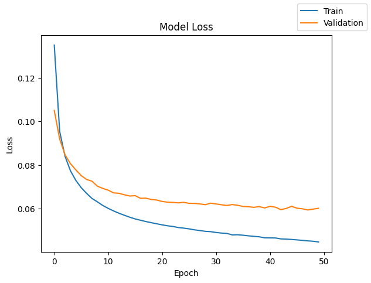

```python
plot(history,'loss')
```

```python
model_0_train_perf = model_performance_classification(model_0, X_train, y_train)
model_0_train_perf
```

```
438/438 ━━━━━━━━━━━━━━━━━━━━ 0s 781us/step
```

|  | Accuracy | Recall | Precision | F1 Score |
| --- | --- | --- | --- | --- |
| 0 | 0.990929 | 0.926755 | 0.985434 | 0.953965 |

```python
model_0_val_perf = model_performance_classification(model_0,X_val,y_val)
model_0_val_perf
```

```
188/188 ━━━━━━━━━━━━━━━━━━━━ 0s 2ms/step
```

|  | Accuracy | Recall | Precision | F1 Score |
| --- | --- | --- | --- | --- |
| 0 | 0.989 | 0.91362 | 0.979224 | 0.943703 |

```python
y_train_pred_0 = model_0.predict(X_train)
y_val_pred_0 = model_0.predict(X_val)
```

```
438/438 ━━━━━━━━━━━━━━━━━━━━ 1s 1ms/step
188/188 ━━━━━━━━━━━━━━━━━━━━ 0s 795us/step
```

```python
print("Classification Report - Train data Model_0",end="\n\n")
cr_train_model_0 = classification_report(y_train,y_train_pred_0>0.5)
print(cr_train_model_0)
```

```
Classification Report - Train data Model_0

              precision    recall  f1-score   support

         0.0       0.99      1.00      1.00     13223
         1.0       0.98      0.85      0.91       777

    accuracy                           0.99     14000
   macro avg       0.99      0.93      0.95     14000
weighted avg       0.99      0.99      0.99     14000
```

- It is extremely strong at predicting “No Failure”
- It is reasonably good at predicting failures
- It is still missing some failures

Recall = 0.85

This is the key metric for my problem.

It means:

- the model catches 85% of real generator failures
- but misses about 15% of failures

Those missed failures become:

- expensive replacements,
- downtime,
- maintenance risk.

So this is good, but should be improved

Accuracy is misleading here because the dataset is imbalanced.

We have:

- 13,223 normal cases
- only 777 failures

So the model can get high accuracy mainly by predicting the majority class correctly.

For predictive maintenance: Recall and F1 are more important than Accuracy.

```python
print("Classification Report - Validation data Model_0",end="\n\n")
cr_val_model_0 = classification_report(y_val,y_val_pred_0>0.5)
print(cr_val_model_0)
```

```
Classification Report - Validation data Model_0

              precision    recall  f1-score   support

         0.0       0.99      1.00      0.99      5667
         1.0       0.97      0.83      0.89       333

    accuracy                           0.99      6000
   macro avg       0.98      0.91      0.94      6000
weighted avg       0.99      0.99      0.99      6000
```

While model is not overfitting, Precision is good, F1 Score is blanced, but the 0.83 Recall should be improved.

# **Model Performance Improvement**

## Model 1 : Add two hidden layers. Starting with 128, 64.

```python
# clears the current Keras session, resetting all layers and models previously created, freeing up memory and resources.
tf.keras.backend.clear_session()
```

```python
#Initializing the neural network for Model 1
model_1 = Sequential()
model_1.add(Dense(128, activation="relu", input_dim=X_train.shape[1]))
model_1.add(Dense(64, activation="relu", input_dim=X_train.shape[1]))
model_1.add(Dense(1, activation="sigmoid"))
```

```python
model_1.summary()
```

```
Model: "sequential"
```

```
┏━━━━━━━━━━━━━━━━━━━━━━━━━━━━━━━━━┳━━━━━━━━━━━━━━━━━━━━━━━━┳━━━━━━━━━━━━━━━┓
┃ Layer (type)                    ┃ Output Shape           ┃       Param # ┃
┡━━━━━━━━━━━━━━━━━━━━━━━━━━━━━━━━━╇━━━━━━━━━━━━━━━━━━━━━━━━╇━━━━━━━━━━━━━━━┩
│ dense (Dense)                   │ (None, 128)            │         5,248 │
├─────────────────────────────────┼────────────────────────┼───────────────┤
│ dense_1 (Dense)                 │ (None, 64)             │         8,256 │
├─────────────────────────────────┼────────────────────────┼───────────────┤
│ dense_2 (Dense)                 │ (None, 1)              │            65 │
└─────────────────────────────────┴────────────────────────┴───────────────┘
```

```
 Total params: 13,569 (53.00 KB)
```

```
 Trainable params: 13,569 (53.00 KB)
```

```
 Non-trainable params: 0 (0.00 B)
```

```python
optimizer_1 = tf.keras.optimizers.SGD()
model_1.compile(loss='binary_crossentropy', optimizer=optimizer_1, metrics=['Recall'])
```

```python
start_1 = time.time()
history_1 = model_1.fit(X_train, y_train, validation_data=(X_val, y_val), batch_size=batch_size, epochs=epochs)
end_1 = time.time()
```

```
438/438 ━━━━━━━━━━━━━━━━━━━━ 1s 2ms/step - Recall: 0.4067 - loss: 0.1261 - val_Recall: 0.6276 - val_loss: 0.1002
438/438 ━━━━━━━━━━━━━━━━━━━━ 1s 2ms/step - Recall: 0.6718 - loss: 0.0821 - val_Recall: 0.7477 - val_loss: 0.0850
438/438 ━━━━━━━━━━━━━━━━━━━━ 1s 2ms/step - Recall: 0.7439 - loss: 0.0706 - val_Recall: 0.7538 - val_loss: 0.0773
438/438 ━━━━━━━━━━━━━━━━━━━━ 1s 3ms/step - Recall: 0.7709 - loss: 0.0644 - val_Recall: 0.7898 - val_loss: 0.0730
438/438 ━━━━━━━━━━━━━━━━━━━━ 1s 2ms/step - Recall: 0.8057 - loss: 0.0601 - val_Recall: 0.7928 - val_loss: 0.0693
438/438 ━━━━━━━━━━━━━━━━━━━━ 1s 2ms/step - Recall: 0.8211 - loss: 0.0572 - val_Recall: 0.7958 - val_loss: 0.0668
438/438 ━━━━━━━━━━━━━━━━━━━━ 1s 2ms/step - Recall: 0.8263 - loss: 0.0546 - val_Recall: 0.8078 - val_loss: 0.0666
438/438 ━━━━━━━━━━━━━━━━━━━━ 1s 2ms/step - Recall: 0.8275 - loss: 0.0528 - val_Recall: 0.8138 - val_loss: 0.0650
438/438 ━━━━━━━━━━━━━━━━━━━━ 1s 2ms/step - Recall: 0.8468 - loss: 0.0512 - val_Recall: 0.8078 - val_loss: 0.0643
438/438 ━━━━━━━━━━━━━━━━━━━━ 1s 2ms/step - Recall: 0.8430 - loss: 0.0494 - val_Recall: 0.8048 - val_loss: 0.0638
438/438 ━━━━━━━━━━━━━━━━━━━━ 1s 2ms/step - Recall: 0.8494 - loss: 0.0484 - val_Recall: 0.8198 - val_loss: 0.0625
438/438 ━━━━━━━━━━━━━━━━━━━━ 1s 2ms/step - Recall: 0.8597 - loss: 0.0472 - val_Recall: 0.8078 - val_loss: 0.0622
438/438 ━━━━━━━━━━━━━━━━━━━━ 1s 2ms/step - Recall: 0.8559 - loss: 0.0459 - val_Recall: 0.8138 - val_loss: 0.0612
438/438 ━━━━━━━━━━━━━━━━━━━━ 1s 2ms/step - Recall: 0.8584 - loss: 0.0450 - val_Recall: 0.8228 - val_loss: 0.0611
438/438 ━━━━━━━━━━━━━━━━━━━━ 1s 2ms/step - Recall: 0.8649 - loss: 0.0443 - val_Recall: 0.8288 - val_loss: 0.0612
438/438 ━━━━━━━━━━━━━━━━━━━━ 1s 2ms/step - Recall: 0.8687 - loss: 0.0432 - val_Recall: 0.8318 - val_loss: 0.0597
438/438 ━━━━━━━━━━━━━━━━━━━━ 1s 3ms/step - Recall: 0.8726 - loss: 0.0427 - val_Recall: 0.8318 - val_loss: 0.0590
438/438 ━━━━━━━━━━━━━━━━━━━━ 1s 2ms/step - Recall: 0.8662 - loss: 0.0420 - val_Recall: 0.8318 - val_loss: 0.0593
438/438 ━━━━━━━━━━━━━━━━━━━━ 1s 2ms/step - Recall: 0.8739 - loss: 0.0410 - val_Recall: 0.8348 - val_loss: 0.0586
438/438 ━━━━━━━━━━━━━━━━━━━━ 1s 2ms/step - Recall: 0.8739 - loss: 0.0404 - val_Recall: 0.8408 - val_loss: 0.0584
438/438 ━━━━━━━━━━━━━━━━━━━━ 1s 2ms/step - Recall: 0.8777 - loss: 0.0399 - val_Recall: 0.8408 - val_loss: 0.0575
438/438 ━━━━━━━━━━━━━━━━━━━━ 1s 2ms/step - Recall: 0.8777 - loss: 0.0395 - val_Recall: 0.8438 - val_loss: 0.0590
438/438 ━━━━━━━━━━━━━━━━━━━━ 1s 2ms/step - Recall: 0.8816 - loss: 0.0390 - val_Recall: 0.8438 - val_loss: 0.0584
438/438 ━━━━━━━━━━━━━━━━━━━━ 1s 2ms/step - Recall: 0.8777 - loss: 0.0380 - val_Recall: 0.8318 - val_loss: 0.0596
438/438 ━━━━━━━━━━━━━━━━━━━━ 1s 2ms/step - Recall: 0.8790 - loss: 0.0378 - val_Recall: 0.8378 - val_loss: 0.0577
438/438 ━━━━━━━━━━━━━━━━━━━━ 1s 2ms/step - Recall: 0.8829 - loss: 0.0373 - val_Recall: 0.8408 - val_loss: 0.0592
438/438 ━━━━━━━━━━━━━━━━━━━━ 1s 2ms/step - Recall: 0.8829 - loss: 0.0368 - val_Recall: 0.8438 - val_loss: 0.0566
438/438 ━━━━━━━━━━━━━━━━━━━━ 1s 2ms/step - Recall: 0.8867 - loss: 0.0360 - val_Recall: 0.8348 - val_loss: 0.0596
438/438 ━━━━━━━━━━━━━━━━━━━━ 1s 3ms/step - Recall: 0.8880 - loss: 0.0359 - val_Recall: 0.8468 - val_loss: 0.0573
438/438 ━━━━━━━━━━━━━━━━━━━━ 1s 3ms/step - Recall: 0.8855 - loss: 0.0350 - val_Recall: 0.8348 - val_loss: 0.0584
438/438 ━━━━━━━━━━━━━━━━━━━━ 1s 2ms/step - Recall: 0.8906 - loss: 0.0347 - val_Recall: 0.8438 - val_loss: 0.0571
438/438 ━━━━━━━━━━━━━━━━━━━━ 1s 2ms/step - Recall: 0.8906 - loss: 0.0345 - val_Recall: 0.8498 - val_loss: 0.0570
438/438 ━━━━━━━━━━━━━━━━━━━━ 1s 2ms/step - Recall: 0.8919 - loss: 0.0343 - val_Recall: 0.8438 - val_loss: 0.0582
438/438 ━━━━━━━━━━━━━━━━━━━━ 1s 2ms/step - Recall: 0.8906 - loss: 0.0339 - val_Recall: 0.8438 - val_loss: 0.0569
438/438 ━━━━━━━━━━━━━━━━━━━━ 1s 2ms/step - Recall: 0.8906 - loss: 0.0333 - val_Recall: 0.8468 - val_loss: 0.0561
438/438 ━━━━━━━━━━━━━━━━━━━━ 1s 2ms/step - Recall: 0.8958 - loss: 0.0327 - val_Recall: 0.8348 - val_loss: 0.0607
438/438 ━━━━━━━━━━━━━━━━━━━━ 1s 2ms/step - Recall: 0.8919 - loss: 0.0327 - val_Recall: 0.8408 - val_loss: 0.0571
438/438 ━━━━━━━━━━━━━━━━━━━━ 1s 2ms/step - Recall: 0.8932 - loss: 0.0321 - val_Recall: 0.8529 - val_loss: 0.0567
438/438 ━━━━━━━━━━━━━━━━━━━━ 1s 2ms/step - Recall: 0.8970 - loss: 0.0319 - val_Recall: 0.8438 - val_loss: 0.0589
438/438 ━━━━━━━━━━━━━━━━━━━━ 1s 2ms/step - Recall: 0.9009 - loss: 0.0318 - val_Recall: 0.8529 - val_loss: 0.0556
438/438 ━━━━━━━━━━━━━━━━━━━━ 1s 2ms/step - Recall: 0.8945 - loss: 0.0311 - val_Recall: 0.8589 - val_loss: 0.0563
438/438 ━━━━━━━━━━━━━━━━━━━━ 1s 2ms/step - Recall: 0.8958 - loss: 0.0308 - val_Recall: 0.8378 - val_loss: 0.0568
438/438 ━━━━━━━━━━━━━━━━━━━━ 1s 3ms/step - Recall: 0.8970 - loss: 0.0307 - val_Recall: 0.8529 - val_loss: 0.0574
438/438 ━━━━━━━━━━━━━━━━━━━━ 1s 2ms/step - Recall: 0.9009 - loss: 0.0303 - val_Recall: 0.8408 - val_loss: 0.0562
438/438 ━━━━━━━━━━━━━━━━━━━━ 1s 2ms/step - Recall: 0.8970 - loss: 0.0301 - val_Recall: 0.8438 - val_loss: 0.0575
438/438 ━━━━━━━━━━━━━━━━━━━━ 1s 2ms/step - Recall: 0.8996 - loss: 0.0297 - val_Recall: 0.8408 - val_loss: 0.0587
438/438 ━━━━━━━━━━━━━━━━━━━━ 1s 2ms/step - Recall: 0.9022 - loss: 0.0293 - val_Recall: 0.8378 - val_loss: 0.0584
438/438 ━━━━━━━━━━━━━━━━━━━━ 1s 2ms/step - Recall: 0.9009 - loss: 0.0290 - val_Recall: 0.8529 - val_loss: 0.0576
438/438 ━━━━━━━━━━━━━━━━━━━━ 1s 2ms/step - Recall: 0.8996 - loss: 0.0287 - val_Recall: 0.8589 - val_loss: 0.0581
438/438 ━━━━━━━━━━━━━━━━━━━━ 1s 2ms/step - Recall: 0.9060 - loss: 0.0284 - val_Recall: 0.8529 - val_loss: 0.0585
```

```python
print("Time taken in seconds ", end_1 - start_1)
```

```
Time taken in seconds  45.76365613937378
```

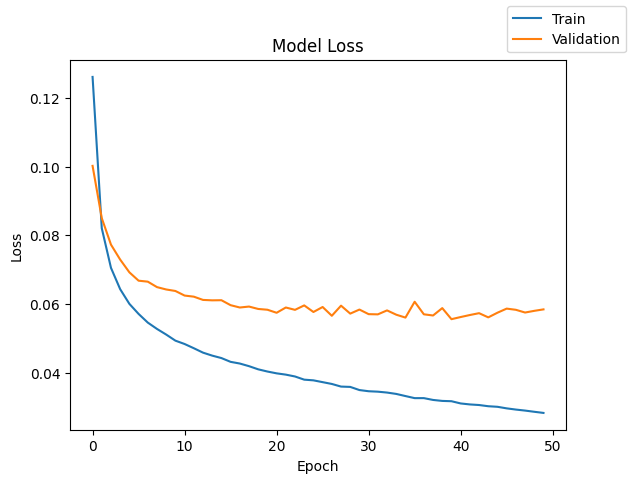

```python
plot(history_1, 'loss')
```

# Epoch 50 , gets us to fairly low losses.

```python
model_1_train_perf = model_performance_classification(model_1, X_train, y_train)
model_1_train_perf
```

```
438/438 ━━━━━━━━━━━━━━━━━━━━ 0s 794us/step
```

|  | Accuracy | Recall | Precision | F1 Score |
| --- | --- | --- | --- | --- |
| 0 | 0.994643 | 0.954766 | 0.993855 | 0.973401 |

```python
model_1_val_perf = model_performance_classification(model_1, X_val, y_val)
model_1_val_perf
```

```
188/188 ━━━━━━━━━━━━━━━━━━━━ 0s 810us/step
```

|  | Accuracy | Recall | Precision | F1 Score |
| --- | --- | --- | --- | --- |
| 0 | 0.9895 | 0.925191 | 0.972213 | 0.947309 |

```python
y_train_pred_1 = model_1.predict(X_train)
y_val_pred_1 = model_1.predict(X_val)
```

```
438/438 ━━━━━━━━━━━━━━━━━━━━ 0s 820us/step
188/188 ━━━━━━━━━━━━━━━━━━━━ 0s 807us/step
```

```python
print("Classification Report - Train data Model_1", end="\n\n")
cr_train_model_1 = classification_report(y_train, y_train_pred_1 > 0.5)
print(cr_train_model_1)
```

```
Classification Report - Train data Model_1

              precision    recall  f1-score   support

         0.0       0.99      1.00      1.00     13223
         1.0       0.99      0.91      0.95       777

    accuracy                           0.99     14000
   macro avg       0.99      0.95      0.97     14000
weighted avg       0.99      0.99      0.99     14000
```

```python
print("Classification Report - Validation data Model_1", end="\n\n")
cr_val_model_1 = classification_report(y_val, y_val_pred_1 > 0.5)
print(cr_val_model_1)
```

```
Classification Report - Validation data Model_1

              precision    recall  f1-score   support

         0.0       0.99      1.00      0.99      5667
         1.0       0.95      0.85      0.90       333

    accuracy                           0.99      6000
   macro avg       0.97      0.93      0.95      6000
weighted avg       0.99      0.99      0.99      6000
```

Model 1, with its added layers, shows a slight improvement in detecting generator failures, increasing Recall from 0.83 to 0.85, and F1-score from 0.89 to 0.90 on the validation set, compared to Model 0. This indicates a better balance between identifying failures and controlling false alarms, making it a step forward in our predictive maintenance strategy.

## Model 2: Increasing hidden layers and adding drop out

Introduce Regularization, Add drop out Rate of 50% after the first hidden layer. Add one more hidden layer, start from 256, 128, 64

```python
# clears the current Keras session, resetting all layers and models previously created, freeing up memory and resources.
tf.keras.backend.clear_session()
```

```python
#Initializing the neural network for Model 2
model_2 = Sequential()
model_2.add(Dense(256, activation="relu", input_dim=X_train.shape[1]))
model_2.add(Dropout(0.5)) # Drop out rate
model_2.add(Dense(128, activation="relu", input_dim=X_train.shape[1]))
model_2.add(Dense(64, activation="relu", input_dim=X_train.shape[1]))
model_2.add(Dense(1, activation="sigmoid"))
```

```python
model_2.summary()
```

```
Model: "sequential"
```

```
┏━━━━━━━━━━━━━━━━━━━━━━━━━━━━━━━━━┳━━━━━━━━━━━━━━━━━━━━━━━━┳━━━━━━━━━━━━━━━┓
┃ Layer (type)                    ┃ Output Shape           ┃       Param # ┃
┡━━━━━━━━━━━━━━━━━━━━━━━━━━━━━━━━━╇━━━━━━━━━━━━━━━━━━━━━━━━╇━━━━━━━━━━━━━━━┩
│ dense (Dense)                   │ (None, 256)            │        10,496 │
├─────────────────────────────────┼────────────────────────┼───────────────┤
│ dropout (Dropout)               │ (None, 256)            │             0 │
├─────────────────────────────────┼────────────────────────┼───────────────┤
│ dense_1 (Dense)                 │ (None, 128)            │        32,896 │
├─────────────────────────────────┼────────────────────────┼───────────────┤
│ dense_2 (Dense)                 │ (None, 64)             │         8,256 │
├─────────────────────────────────┼────────────────────────┼───────────────┤
│ dense_3 (Dense)                 │ (None, 1)              │            65 │
└─────────────────────────────────┴────────────────────────┴───────────────┘
```

```
 Total params: 51,713 (202.00 KB)
```

```
 Trainable params: 51,713 (202.00 KB)
```

```
 Non-trainable params: 0 (0.00 B)
```

```python
optimizer_2 = tf.keras.optimizers.SGD()
model_2.compile(loss='binary_crossentropy', optimizer=optimizer_2, metrics=['Recall'])
```

```python
start_2 = time.time()
history_2 = model_2.fit(X_train, y_train, validation_data=(X_val, y_val), batch_size=batch_size, epochs=epochs)
end_2 = time.time()
```

```
438/438 ━━━━━━━━━━━━━━━━━━━━ 2s 3ms/step - Recall: 0.2368 - loss: 0.1724 - val_Recall: 0.4655 - val_loss: 0.1138
438/438 ━━━━━━━━━━━━━━━━━━━━ 1s 2ms/step - Recall: 0.5212 - loss: 0.1123 - val_Recall: 0.6396 - val_loss: 0.0936
438/438 ━━━━━━━━━━━━━━━━━━━━ 1s 2ms/step - Recall: 0.5959 - loss: 0.0999 - val_Recall: 0.7117 - val_loss: 0.0816
438/438 ━━━━━━━━━━━━━━━━━━━━ 1s 2ms/step - Recall: 0.6757 - loss: 0.0919 - val_Recall: 0.7327 - val_loss: 0.0752
438/438 ━━━━━━━━━━━━━━━━━━━━ 1s 2ms/step - Recall: 0.7194 - loss: 0.0779 - val_Recall: 0.7628 - val_loss: 0.0709
438/438 ━━━━━━━━━━━━━━━━━━━━ 1s 2ms/step - Recall: 0.7336 - loss: 0.0756 - val_Recall: 0.7808 - val_loss: 0.0677
438/438 ━━━━━━━━━━━━━━━━━━━━ 1s 2ms/step - Recall: 0.7362 - loss: 0.0714 - val_Recall: 0.7808 - val_loss: 0.0661
438/438 ━━━━━━━━━━━━━━━━━━━━ 1s 2ms/step - Recall: 0.7529 - loss: 0.0696 - val_Recall: 0.7958 - val_loss: 0.0627
438/438 ━━━━━━━━━━━━━━━━━━━━ 1s 2ms/step - Recall: 0.7773 - loss: 0.0666 - val_Recall: 0.8078 - val_loss: 0.0613
438/438 ━━━━━━━━━━━━━━━━━━━━ 2s 4ms/step - Recall: 0.7773 - loss: 0.0659 - val_Recall: 0.8018 - val_loss: 0.0601
438/438 ━━━━━━━━━━━━━━━━━━━━ 1s 2ms/step - Recall: 0.7812 - loss: 0.0658 - val_Recall: 0.8048 - val_loss: 0.0601
438/438 ━━━━━━━━━━━━━━━━━━━━ 1s 2ms/step - Recall: 0.7928 - loss: 0.0607 - val_Recall: 0.8078 - val_loss: 0.0584
438/438 ━━━━━━━━━━━━━━━━━━━━ 1s 2ms/step - Recall: 0.8069 - loss: 0.0598 - val_Recall: 0.8408 - val_loss: 0.0573
438/438 ━━━━━━━━━━━━━━━━━━━━ 1s 3ms/step - Recall: 0.8134 - loss: 0.0598 - val_Recall: 0.8348 - val_loss: 0.0562
438/438 ━━━━━━━━━━━━━━━━━━━━ 1s 2ms/step - Recall: 0.8160 - loss: 0.0562 - val_Recall: 0.8348 - val_loss: 0.0559
438/438 ━━━━━━━━━━━━━━━━━━━━ 1s 2ms/step - Recall: 0.8250 - loss: 0.0550 - val_Recall: 0.8408 - val_loss: 0.0552
438/438 ━━━━━━━━━━━━━━━━━━━━ 1s 2ms/step - Recall: 0.8160 - loss: 0.0553 - val_Recall: 0.8529 - val_loss: 0.0550
438/438 ━━━━━━━━━━━━━━━━━━━━ 1s 2ms/step - Recall: 0.8288 - loss: 0.0532 - val_Recall: 0.8408 - val_loss: 0.0541
438/438 ━━━━━━━━━━━━━━━━━━━━ 1s 2ms/step - Recall: 0.8237 - loss: 0.0535 - val_Recall: 0.8498 - val_loss: 0.0536
438/438 ━━━━━━━━━━━━━━━━━━━━ 2s 4ms/step - Recall: 0.8237 - loss: 0.0544 - val_Recall: 0.8438 - val_loss: 0.0529
438/438 ━━━━━━━━━━━━━━━━━━━━ 1s 2ms/step - Recall: 0.8353 - loss: 0.0523 - val_Recall: 0.8378 - val_loss: 0.0529
438/438 ━━━━━━━━━━━━━━━━━━━━ 1s 2ms/step - Recall: 0.8468 - loss: 0.0517 - val_Recall: 0.8438 - val_loss: 0.0526
438/438 ━━━━━━━━━━━━━━━━━━━━ 1s 2ms/step - Recall: 0.8340 - loss: 0.0518 - val_Recall: 0.8468 - val_loss: 0.0522
438/438 ━━━━━━━━━━━━━━━━━━━━ 1s 2ms/step - Recall: 0.8494 - loss: 0.0494 - val_Recall: 0.8498 - val_loss: 0.0517
438/438 ━━━━━━━━━━━━━━━━━━━━ 1s 2ms/step - Recall: 0.8507 - loss: 0.0484 - val_Recall: 0.8498 - val_loss: 0.0516
438/438 ━━━━━━━━━━━━━━━━━━━━ 1s 2ms/step - Recall: 0.8520 - loss: 0.0487 - val_Recall: 0.8438 - val_loss: 0.0523
438/438 ━━━━━━━━━━━━━━━━━━━━ 1s 2ms/step - Recall: 0.8353 - loss: 0.0498 - val_Recall: 0.8529 - val_loss: 0.0517
438/438 ━━━━━━━━━━━━━━━━━━━━ 1s 2ms/step - Recall: 0.8559 - loss: 0.0482 - val_Recall: 0.8438 - val_loss: 0.0522
438/438 ━━━━━━━━━━━━━━━━━━━━ 1s 2ms/step - Recall: 0.8481 - loss: 0.0475 - val_Recall: 0.8559 - val_loss: 0.0509
438/438 ━━━━━━━━━━━━━━━━━━━━ 1s 3ms/step - Recall: 0.8571 - loss: 0.0463 - val_Recall: 0.8559 - val_loss: 0.0510
438/438 ━━━━━━━━━━━━━━━━━━━━ 1s 3ms/step - Recall: 0.8636 - loss: 0.0466 - val_Recall: 0.8529 - val_loss: 0.0510
438/438 ━━━━━━━━━━━━━━━━━━━━ 1s 2ms/step - Recall: 0.8623 - loss: 0.0445 - val_Recall: 0.8559 - val_loss: 0.0508
438/438 ━━━━━━━━━━━━━━━━━━━━ 1s 2ms/step - Recall: 0.8546 - loss: 0.0466 - val_Recall: 0.8529 - val_loss: 0.0504
438/438 ━━━━━━━━━━━━━━━━━━━━ 1s 3ms/step - Recall: 0.8507 - loss: 0.0459 - val_Recall: 0.8619 - val_loss: 0.0501
438/438 ━━━━━━━━━━━━━━━━━━━━ 1s 2ms/step - Recall: 0.8674 - loss: 0.0450 - val_Recall: 0.8529 - val_loss: 0.0502
438/438 ━━━━━━━━━━━━━━━━━━━━ 1s 2ms/step - Recall: 0.8636 - loss: 0.0439 - val_Recall: 0.8589 - val_loss: 0.0503
438/438 ━━━━━━━━━━━━━━━━━━━━ 1s 2ms/step - Recall: 0.8649 - loss: 0.0445 - val_Recall: 0.8438 - val_loss: 0.0513
438/438 ━━━━━━━━━━━━━━━━━━━━ 1s 2ms/step - Recall: 0.8649 - loss: 0.0425 - val_Recall: 0.8559 - val_loss: 0.0506
438/438 ━━━━━━━━━━━━━━━━━━━━ 1s 2ms/step - Recall: 0.8674 - loss: 0.0440 - val_Recall: 0.8529 - val_loss: 0.0502
438/438 ━━━━━━━━━━━━━━━━━━━━ 1s 2ms/step - Recall: 0.8713 - loss: 0.0423 - val_Recall: 0.8649 - val_loss: 0.0499
438/438 ━━━━━━━━━━━━━━━━━━━━ 2s 3ms/step - Recall: 0.8752 - loss: 0.0436 - val_Recall: 0.8649 - val_loss: 0.0500
438/438 ━━━━━━━━━━━━━━━━━━━━ 2s 2ms/step - Recall: 0.8700 - loss: 0.0431 - val_Recall: 0.8649 - val_loss: 0.0501
438/438 ━━━━━━━━━━━━━━━━━━━━ 1s 2ms/step - Recall: 0.8700 - loss: 0.0422 - val_Recall: 0.8559 - val_loss: 0.0502
438/438 ━━━━━━━━━━━━━━━━━━━━ 1s 2ms/step - Recall: 0.8726 - loss: 0.0419 - val_Recall: 0.8649 - val_loss: 0.0500
438/438 ━━━━━━━━━━━━━━━━━━━━ 1s 2ms/step - Recall: 0.8662 - loss: 0.0426 - val_Recall: 0.8619 - val_loss: 0.0497
438/438 ━━━━━━━━━━━━━━━━━━━━ 1s 2ms/step - Recall: 0.8752 - loss: 0.0422 - val_Recall: 0.8649 - val_loss: 0.0503
438/438 ━━━━━━━━━━━━━━━━━━━━ 1s 2ms/step - Recall: 0.8636 - loss: 0.0432 - val_Recall: 0.8559 - val_loss: 0.0500
438/438 ━━━━━━━━━━━━━━━━━━━━ 1s 2ms/step - Recall: 0.8649 - loss: 0.0416 - val_Recall: 0.8709 - val_loss: 0.0497
438/438 ━━━━━━━━━━━━━━━━━━━━ 1s 2ms/step - Recall: 0.8713 - loss: 0.0417 - val_Recall: 0.8709 - val_loss: 0.0500
438/438 ━━━━━━━━━━━━━━━━━━━━ 1s 3ms/step - Recall: 0.8777 - loss: 0.0398 - val_Recall: 0.8709 - val_loss: 0.0498
```